# Apriori

# Apriori Analysis

The dataset for this competition is a relational set of files describing customers’ orders over time. The goal of the competition is to predict which products will be in a user’s next order. The dataset is anonymized and contains a sample of over 3 million grocery orders from more than 200,000 Instacart users. For each user, we provide between 4 and 100 of their orders, with the sequence of products purchased in each order. We also provide the week and hour of day the order was placed, and a relative measure of time between orders. For more information, see the blog post accompanying its public release.

## File descriptions

Each entity (customer, product, order, aisle, etc.) has an associated unique id. Most of the files and variable names should be self-explanatory.

source: https://www.kaggle.com/code/shubhendra7/market-basket-analysis-r-language/data

```r
#install.packages("IRdisplay")
library(dplyr)
library(tidyverse)
library(data.table)
library(arules)
```

```r
library(arulesViz)
library(plotly)
library(IRdisplay)
```

## Install SparkR

Since the analysis itself considered brief, there may be better approach to create association rules with sparkR. This approach enhance the computing capabilities by enabling distributed processing across clusters, but in this example lets try using single cluster.The dataset also contain large amount of data around 32 Million, this is another reason to utilize spark in r.

The spark version used is spark 3.2.2 and hadoop 3.2 for the distributed file repository.

source : https://sbartek.github.io/sparkRInstall/installSparkReasyWay.html https://github.com/cdarlint/winutils/blob/master/hadoop-3.2.2/bin/winutils.exe

```r
#library(dplyr)
#install.packages('sparklyr', '1.6.3')
#packageurl = "https://cran.r-project.org/src/contrib/Archive/sparklyr/sparklyr_1.6.2.tar.gz"
#install.packages("sparklyr")
#packageVersion("sparklyr")
#library(sparklyr)
#spark_install("3.2")
#spark_available_versions()
#spark_installed_versions()
#spark_uninstall(version="2.4.3", hadoop="2.7")
#options(sparklyr.log.console=TRUE)
#sc = spark_connect(master="local", version="3.2.2")

#library(SparkR, lib.loc = c(file.path(Sys.getenv("SPARK_HOME"), "R", "lib")))
#sparkR.session(master = "local[*]", sparkConfig = list(spark.driver.memory = "3g"))

#sparkR.stop()
```

## Read Dataset

source:https://spark.apache.org/docs/2.1.0/api/R/read.df.html

```r
#schema_products = structType(structField("product_id","string"),
#                             structField("product_name","string"),
#                             structField("aisle_id", "string"),
#                             structField("department_id", "string"))

#df_products = read.df(path="D:/Kuliah/semester_1/data_mining_and_business_intelligence/pertemuan_11/tugas/products.csv", source="csv", schema=schema_products, header=TRUE)

#head(df_products)

#schema_orders = structType(structField("order_id","string"),
#                           structField("product_id","string"),
#                           structField("add_to_cart_order","string"),
#                           structField("reordered","string"))

#df_orders = read.df(path="D:/Kuliah/semester_1/data_mining_and_business_intelligence/pertemuan_11/tugas/order_products__prior.csv", #source="csv",schema=schema_orders, header=TRUE, delimiter=";")

#head(df_orders)

df_products_ns = read.csv("D:/Kuliah/semester_1/data_mining_and_business_intelligence/pertemuan_11/tugas/products.csv")
#str(df_products_ns)

df_order_ns = read.csv("D:/Kuliah/semester_1/data_mining_and_business_intelligence/pertemuan_11/tugas/order_products__prior.csv")
#str(df_order_ns)
```

## Parallel Apriori Algorithm in SPARK

source:

https://www.itm-conferences.org/articles/itmconf/pdf/2021/05/itmconf_icacc2021_03046.pdf https://spark.apache.org/docs/3.2.2/sparkr.html#starting-up-sparksession https://spark.apache.org/docs/1.5.0/api/R/select.html https://spark.apache.org/docs/1.6.0/api/R/groupBy.html

```r
# Register this SparkDataFrame as a temporary view.
#createOrReplaceTempView(df_orders, "df_orders")
# Register this SparkDataFrame as a temporary view.
#createOrReplaceTempView(df_products, "df_products")

basket_data = merge(df_order_ns, df_products_ns, by = "product_id")

#head(basket_data)


#basket_data = df_orders %>%
#  merge(df_products, by.x="product_id", by.y="product_id", all.x=TRUE)%>%
#  selectExpr("order_id","product_name")%>%
#  collect()


basket_input = split(basket_data$product_name,basket_data$order_id)
```

# Spark

```r
#df <- selectExpr(createDataFrame(data.frame(rawItems = c("1,2,5", "1,2,3,5", "1,2"))), "split(rawItems, ',') AS items")

#head(df)

#fpm <- spark.fpGrowth(df, itemsCol="items", minSupport=0.5, minConfidence=0.6)

#spark.freqItemsets(fpm)

#spark.associationRules(fpm)

#predict(fpm, df)

#sparkR.stop()
```

Unfortunately, since spark R doesnt have method to convert dataframe to list / vector, here afterwards, the analysis stick with R only.

```r
transactions=as(basket_input, 'transactions')
head(transactions)
```

```
## transactions in sparse format with
##  6 transactions (rows) and
##  49677 items (columns)
```

```r
length(transactions)
```

```
## [1] 3214874
```

```r
myrules=apriori(transactions, list(support=0.00075, confidence=0.5, maxlen= 5))
```

```
## Apriori
##
## Parameter specification:
##  confidence minval smax arem  aval originalSupport maxtime support minlen
##         0.5    0.1    1 none FALSE            TRUE       5 0.00075      1
##  maxlen target  ext
##       5  rules TRUE
##
## Algorithmic control:
##  filter tree heap memopt load sort verbose
##     0.1 TRUE TRUE  FALSE TRUE    2    TRUE
##
## Absolute minimum support count: 2411
##
## set item appearances ...[0 item(s)] done [0.00s].
## set transactions ...[49677 item(s), 3214874 transaction(s)] done [18.72s].
## sorting and recoding items ... [2375 item(s)] done [0.39s].
## creating transaction tree ... done [4.27s].
## checking subsets of size 1 2 3 4 done [1.73s].
## writing ... [7 rule(s)] done [0.01s].
## creating S4 object  ... done [0.76s].
```

```r
summary(myrules)
```

```
## set of 7 rules
##
## rule length distribution (lhs + rhs):sizes
## 2 3
## 2 5
##
##    Min. 1st Qu.  Median    Mean 3rd Qu.    Max.
##   2.000   2.500   3.000   2.714   3.000   3.000
##
## summary of quality measures:
##     support            confidence        coverage             lift
##  Min.   :0.0007705   Min.   :0.5188   Min.   :0.001308   Min.   : 21.98
##  1st Qu.:0.0008336   1st Qu.:0.5496   1st Qu.:0.001388   1st Qu.: 27.12
##  Median :0.0008504   Median :0.5745   Median :0.001467   Median : 63.91
##  Mean   :0.0009628   Mean   :0.5810   Mean   :0.001678   Mean   :121.99
##  3rd Qu.:0.0010360   3rd Qu.:0.6132   3rd Qu.:0.001770   3rd Qu.:195.86
##  Max.   :0.0013792   Max.   :0.6482   Max.   :0.002658   Max.   :322.07
##      count
##  Min.   :2477
##  1st Qu.:2680
##  Median :2734
##  Mean   :3095
##  3rd Qu.:3330
##  Max.   :4434
##
## mining info:
##          data ntransactions support confidence
##  transactions       3214874 0.00075        0.5
##                                                                                             call
##  apriori(data = transactions, parameter = list(support = 0.00075, confidence = 0.5, maxlen = 5))
```

```r
inspect(myrules[1:7])
```

```
##     lhs                                                        rhs                                                          support confidence    coverage      lift count
## [1] {Almond Milk Blueberry Yogurt}                          => {Almond Milk Strawberry Yogurt}                         0.0008404684  0.5729432 0.001466932 322.07381  2702
## [2] {Almond Milk Peach Yogurt}                              => {Almond Milk Strawberry Yogurt}                         0.0007704812  0.5262375 0.001464132 295.81873  2477
## [3] {Lime Sparkling Water,
##      Sparkling Water Berry}                                 => {Sparkling Water Grapefruit}                            0.0008267820  0.6321046 0.001307983  26.77881  2658
## [4] {Non Fat Raspberry Yogurt,
##      Vanilla Skyr Nonfat Yogurt}                            => {Icelandic Style Skyr Blueberry Non-fat Yogurt}         0.0009107666  0.5744556 0.001585443  95.90291  2928
## [5] {Lime Sparkling Water,
##      Peach Pear Flavored Sparkling Water}                   => {Sparkling Water Grapefruit}                            0.0008504221  0.6481745 0.001312027  27.45960  2734
## [6] {Total 2% Lowfat Greek Strained Yogurt With Blueberry,
##      Total 2% Lowfat Greek Strained Yogurt with Peach}      => {Total 2% with Strawberry Lowfat Greek Strained Yogurt} 0.0011611653  0.5942375 0.001954042  63.90789  3733
## [7] {Lime Sparkling Water,
##      Sparkling Lemon Water}                                 => {Sparkling Water Grapefruit}                            0.0013792142  0.5188392 0.002658269  21.98037  4434
```

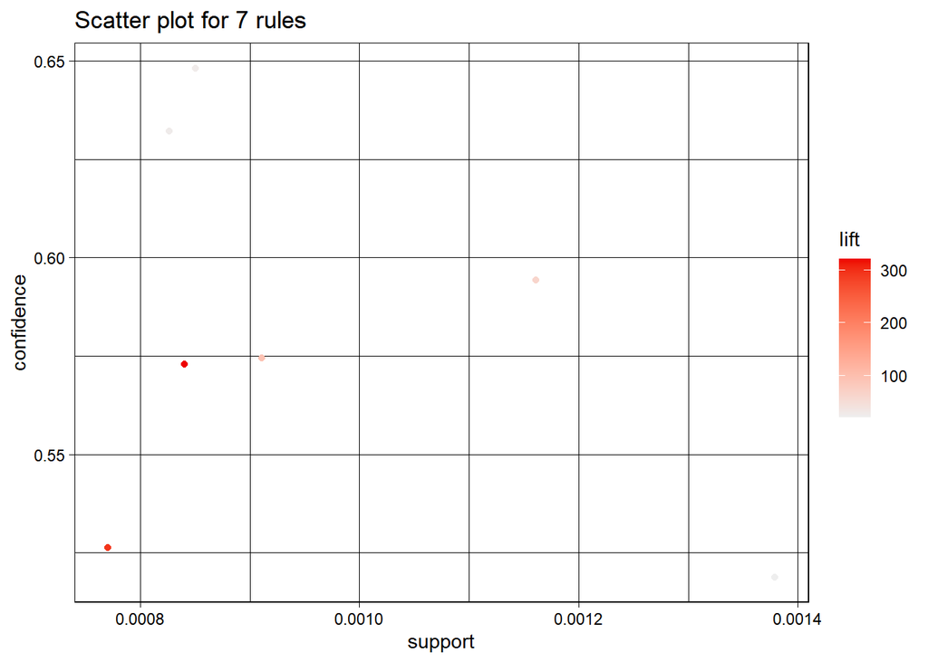

```r
plot(myrules, jitter=0)
```

[figure not shown]

```r
plot(myrules, method="grouped", control=list(k=7))
```

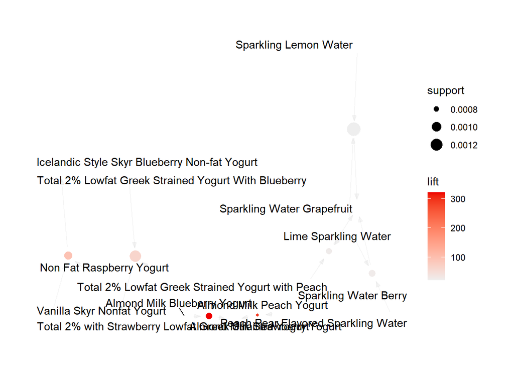

```r
plot(myrules[1:7], method="graph")
```

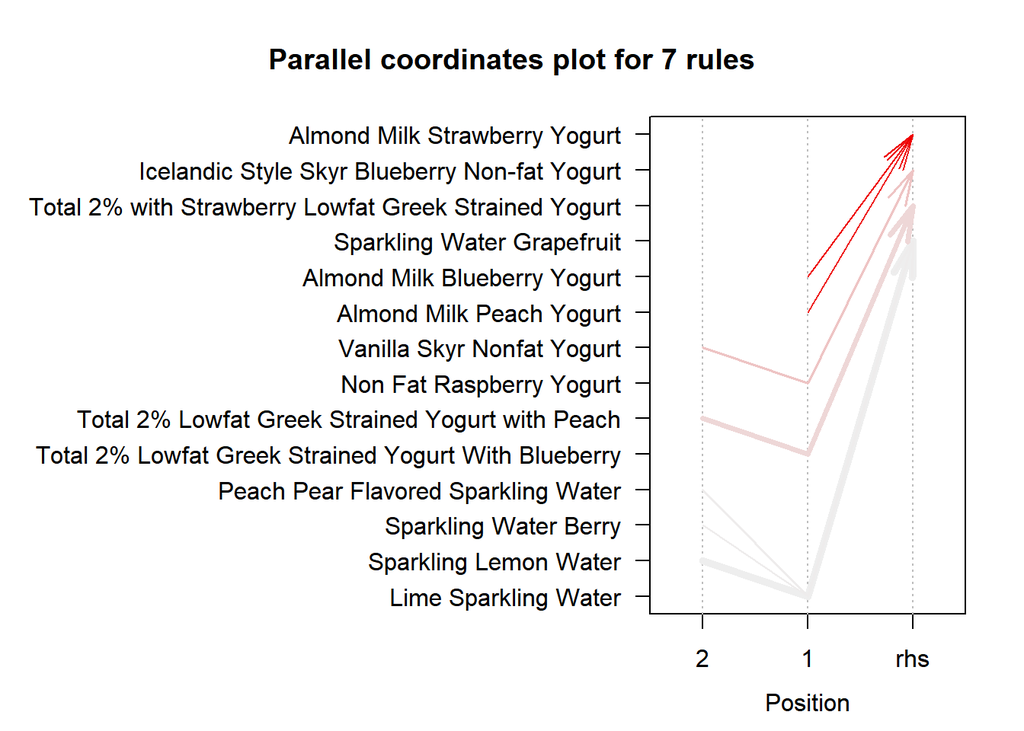

```r
plot(myrules[1:7], method="paracoord")
```